# Customer-Churn Prediction in Telecom

## Essaki

## Big-Data using Spark

## Analysis on Churn.csv Dataset

## **__**

## Telecom Customer Churn

### Introduction

#### I am going to use this Telecom Customer dataset to predict the churn with the Random Forest, Decision Tree and Logistic Regression algorithm.

### Setting Dictionary (path) from cloudera:

```python
import findspark
findspark.init('/opt/cloudera/parcels/SPARK2-2.4.0.cloudera2-1.cdh5.13.3.p0.1041012/lib/spark2/')
```

```python
from pyspark.sql import SparkSession
```

### Setting directory to read our dataset into spark from Hive or Hbase.

```python
# Quetion - 1)
spark_2 = SparkSession.builder.appName('SparkSession2').config('spark.sql.warehouse.dir', 'hdfs://masternode:8020/user/hive/warehouse/').enableHiveSupport().getOrCreate()
```

```python
df = spark_2.read.csv("hdfs://masternode:8020/user/bdhlabnova3/Churn.csv", header=True, inferSchema=True)
```

#### To take brief view of data in spark we use .Show() command:

```python
df.show()
```

```
+-------------+------------+-------+-------+---------+--------+-------------+-----+--------+---------+--------+---------+--------+---------+----------+-----------+---------+----------+-----+--------+--------+
|AccountLength|VMailMessage|DayMins|EveMins|NightMins|IntlMins|CustServCalls|Churn|IntlPlan|VMailPlan|DayCalls|DayCharge|EveCalls|EveCharge|NightCalls|NightCharge|IntlCalls|IntlCharge|State|AreaCode|   Phone|
+-------------+------------+-------+-------+---------+--------+-------------+-----+--------+---------+--------+---------+--------+---------+----------+-----------+---------+----------+-----+--------+--------+
|          128|          25|  265.1|  197.4|    244.7|    10.0|            1|    0|       0|        1|     110|    45.07|      99|    16.78|        91|      11.01|        3|       2.7|   KS|     415|382-4657|
|          107|          26|  161.6|  195.5|    254.4|    13.7|            1|    0|       0|        1|     123|    27.47|     103|    16.62|       103|      11.45|        3|       3.7|   OH|     415|371-7191|
|          137|           0|  243.4|  121.2|    162.6|    12.2|            0|    0|       0|        0|     114|    41.38|     110|     10.3|       104|       7.32|        5|      3.29|   NJ|     415|358-1921|
|           84|           0|  299.4|   61.9|    196.9|     6.6|            2|    0|       1|        0|      71|     50.9|      88|     5.26|        89|       8.86|        7|      1.78|   OH|     408|375-9999|
|           75|           0|  166.7|  148.3|    186.9|    10.1|            3|    0|       1|        0|     113|    28.34|     122|    12.61|       121|       8.41|        3|      2.73|   OK|     415|330-6626|
|          118|           0|  223.4|  220.6|    203.9|     6.3|            0|    0|       1|        0|      98|    37.98|     101|    18.75|       118|       9.18|        6|       1.7|   AL|     510|391-8027|
|          121|          24|  218.2|  348.5|    212.6|     7.5|            3|    0|       0|        1|      88|    37.09|     108|    29.62|       118|       9.57|        7|      2.03|   MA|     510|355-9993|
|          147|           0|  157.0|  103.1|    211.8|     7.1|            0|    0|       1|        0|      79|    26.69|      94|     8.76|        96|       9.53|        6|      1.92|   MO|     415|329-9001|
|          117|           0|  184.5|  351.6|    215.8|     8.7|            1|    0|       0|        0|      97|    31.37|      80|    29.89|        90|       9.71|        4|      2.35|   LA|     408|335-4719|
|          141|          37|  258.6|  222.0|    326.4|    11.2|            0|    0|       1|        1|      84|    43.96|     111|    18.87|        97|      14.69|        5|      3.02|   WV|     415|330-8173|
|           65|           0|  129.1|  228.5|    208.8|    12.7|            4|    1|       0|        0|     137|    21.95|      83|    19.42|       111|        9.4|        6|      3.43|   IN|     415|329-6603|
|           74|           0|  187.7|  163.4|    196.0|     9.1|            0|    0|       0|        0|     127|    31.91|     148|    13.89|        94|       8.82|        5|      2.46|   RI|     415|344-9403|
|          168|           0|  128.8|  104.9|    141.1|    11.2|            1|    0|       0|        0|      96|     21.9|      71|     8.92|       128|       6.35|        2|      3.02|   IA|     408|363-1107|
|           95|           0|  156.6|  247.6|    192.3|    12.3|            3|    0|       0|        0|      88|    26.62|      75|    21.05|       115|       8.65|        5|      3.32|   MT|     510|394-8006|
|           62|           0|  120.7|  307.2|    203.0|    13.1|            4|    0|       0|        0|      70|    20.52|      76|    26.11|        99|       9.14|        6|      3.54|   IA|     415|366-9238|
|          161|           0|  332.9|  317.8|    160.6|     5.4|            4|    1|       0|        0|      67|    56.59|      97|    27.01|       128|       7.23|        9|      1.46|   NY|     415|351-7269|
|           85|          27|  196.4|  280.9|     89.3|    13.8|            1|    0|       0|        1|     139|    33.39|      90|    23.88|        75|       4.02|        4|      3.73|   ID|     408|350-8884|
|           93|           0|  190.7|  218.2|    129.6|     8.1|            3|    0|       0|        0|     114|    32.42|     111|    18.55|       121|       5.83|        3|      2.19|   VT|     510|386-2923|
|           76|          33|  189.7|  212.8|    165.7|    10.0|            1|    0|       0|        1|      66|    32.25|      65|    18.09|       108|       7.46|        5|       2.7|   VA|     510|356-2992|
|           73|           0|  224.4|  159.5|    192.8|    13.0|            1|    0|       0|        0|      90|    38.15|      88|    13.56|        74|       8.68|        2|      3.51|   TX|     415|373-2782|
+-------------+------------+-------+-------+---------+--------+-------------+-----+--------+---------+--------+---------+--------+---------+----------+-----------+---------+----------+-----+--------+--------+
only showing top 20 rows
```

```python
# Here df is our RDD:
df.head()
```

```
Row(AccountLength=128, VMailMessage=25, DayMins=265.1, EveMins=197.4, NightMins=244.7, IntlMins=10.0, CustServCalls=1, Churn=0, IntlPlan=0, VMailPlan=1, DayCalls=110, DayCharge=45.07, EveCalls=99, EveCharge=16.78, NightCalls=91, NightCharge=11.01, IntlCalls=3, IntlCharge=2.7, State='KS', AreaCode=41…
```

## Now here we gonna print our data schema.

### What is database schema ?

### A database schema is the skeleton structure that represents the logical view of the entire database. It defines how the data is organized and how the relations among them are associated. It formulates all the constraints that are to be applied on the data.

```python
df.printSchema()
```

```
root
 |-- AccountLength: integer (nullable = true)
 |-- VMailMessage: integer (nullable = true)
 |-- DayMins: double (nullable = true)
 |-- EveMins: double (nullable = true)
 |-- NightMins: double (nullable = true)
 |-- IntlMins: double (nullable = true)
 |-- CustServCalls: integer (nullable = true)
 |-- Churn: integer (nullable = true)
 |-- IntlPlan: integer (nullable = true)
 |-- VMailPlan: integer (nullable = true)
 |-- DayCalls: integer (nullable = true)
 |-- DayCharge: double (nullable = true)
 |-- EveCalls: integer (nullable = true)
 |-- EveCharge: double (nullable = true)
 |-- NightCalls: integer (nullable = true)
 |-- NightCharge: double (nullable = true)
 |-- IntlCalls: integer (nullable = true)
 |-- IntlCharge: double (nullable = true)
 |-- State: string (nullable = true)
 |-- AreaCode: integer (nullable = true)
 |-- Phone: string (nullable = true)
```

### After a quick view of schema, to see our spark notebook as in a view of python notebook or to analyse the data as per the libararies of pandas, we use:

```python
df.describe().toPandas()
```

|  | summary | AccountLength | VMailMessage | DayMins | EveMins | NightMins | IntlMins | CustServCalls | Churn | IntlPlan | ... | DayCharge | EveCalls | EveCharge | NightCalls | NightCharge | IntlCalls | IntlCharge | State | AreaCode | Phone |
| --- | --- | --- | --- | --- | --- | --- | --- | --- | --- | --- | --- | --- | --- | --- | --- | --- | --- | --- | --- | --- | --- |
| 0 | count | 3333 | 3333 | 3333 | 3333 | 3333 | 3333 | 3333 | 3333 | 3333 | ... | 3333 | 3333 | 3333 | 3333 | 3333 | 3333 | 3333 | 3333 | 3333 | 3333 |
| 1 | mean | 101.06480648064806 | 8.099009900990099 | 179.77509750975116 | 200.98034803480346 | 200.87203720372048 | 10.237293729372933 | 1.5628562856285628 | 0.14491449144914492 | 0.0969096909690969 | ... | 30.562307230723093 | 100.11431143114311 | 17.083540354035392 | 100.10771077107711 | 9.039324932493264 | 4.4794479447944795 | 2.764581458145804 | None | 437.18241824182417 | None |
| 2 | stddev | 39.822105928595676 | 13.688365372038598 | 54.46738920237146 | 50.713844425811985 | 50.57384701365836 | 2.791839548408416 | 1.3154910448664752 | 0.352067423624126 | 0.2958791454844147 | ... | 9.259434553930495 | 19.92262529394312 | 4.310667643110347 | 19.568609346058544 | 2.275872837660027 | 2.4612142705460953 | 0.7537726126630451 | None | 42.37129048560661 | None |
| 3 | min | 1 | 0 | 0.0 | 0.0 | 23.2 | 0.0 | 0 | 0 | 0 | ... | 0.0 | 0 | 0.0 | 33 | 1.04 | 0 | 0.0 | AK | 408 | 327-1058 |
| 4 | max | 243 | 51 | 350.8 | 363.7 | 395.0 | 20.0 | 9 | 1 | 1 | ... | 59.64 | 170 | 30.91 | 175 | 17.77 | 20 | 5.4 | WY | 510 | 422-9964 |

5 rows × 22 columns

```python
import pandas as pd
pd.DataFrame(df.take(10),columns=df.columns)
```

|  | AccountLength | VMailMessage | DayMins | EveMins | NightMins | IntlMins | CustServCalls | Churn | IntlPlan | VMailPlan | ... | DayCharge | EveCalls | EveCharge | NightCalls | NightCharge | IntlCalls | IntlCharge | State | AreaCode | Phone |
| --- | --- | --- | --- | --- | --- | --- | --- | --- | --- | --- | --- | --- | --- | --- | --- | --- | --- | --- | --- | --- | --- |
| 0 | 128 | 25 | 265.1 | 197.4 | 244.7 | 10.0 | 1 | 0 | 0 | 1 | ... | 45.07 | 99 | 16.78 | 91 | 11.01 | 3 | 2.70 | KS | 415 | 382-4657 |
| 1 | 107 | 26 | 161.6 | 195.5 | 254.4 | 13.7 | 1 | 0 | 0 | 1 | ... | 27.47 | 103 | 16.62 | 103 | 11.45 | 3 | 3.70 | OH | 415 | 371-7191 |
| 2 | 137 | 0 | 243.4 | 121.2 | 162.6 | 12.2 | 0 | 0 | 0 | 0 | ... | 41.38 | 110 | 10.30 | 104 | 7.32 | 5 | 3.29 | NJ | 415 | 358-1921 |
| 3 | 84 | 0 | 299.4 | 61.9 | 196.9 | 6.6 | 2 | 0 | 1 | 0 | ... | 50.90 | 88 | 5.26 | 89 | 8.86 | 7 | 1.78 | OH | 408 | 375-9999 |
| 4 | 75 | 0 | 166.7 | 148.3 | 186.9 | 10.1 | 3 | 0 | 1 | 0 | ... | 28.34 | 122 | 12.61 | 121 | 8.41 | 3 | 2.73 | OK | 415 | 330-6626 |
| 5 | 118 | 0 | 223.4 | 220.6 | 203.9 | 6.3 | 0 | 0 | 1 | 0 | ... | 37.98 | 101 | 18.75 | 118 | 9.18 | 6 | 1.70 | AL | 510 | 391-8027 |
| 6 | 121 | 24 | 218.2 | 348.5 | 212.6 | 7.5 | 3 | 0 | 0 | 1 | ... | 37.09 | 108 | 29.62 | 118 | 9.57 | 7 | 2.03 | MA | 510 | 355-9993 |
| 7 | 147 | 0 | 157.0 | 103.1 | 211.8 | 7.1 | 0 | 0 | 1 | 0 | ... | 26.69 | 94 | 8.76 | 96 | 9.53 | 6 | 1.92 | MO | 415 | 329-9001 |
| 8 | 117 | 0 | 184.5 | 351.6 | 215.8 | 8.7 | 1 | 0 | 0 | 0 | ... | 31.37 | 80 | 29.89 | 90 | 9.71 | 4 | 2.35 | LA | 408 | 335-4719 |
| 9 | 141 | 37 | 258.6 | 222.0 | 326.4 | 11.2 | 0 | 0 | 1 | 1 | ... | 43.96 | 111 | 18.87 | 97 | 14.69 | 5 | 3.02 | WV | 415 | 330-8173 |

10 rows × 21 columns

## EDA - Data analysis and feature engineering

```python
# IMPORT LIBRARIES
from pyspark.sql import *
import matplotlib
import matplotlib.pyplot as plt
from numpy import array
import numpy as np
import numpy as np
import datetime
from pyspark.sql.functions import *
from pyspark import SparkContext
```

```python
num_feat = [i[0] for i in df.dtypes if i[1]=='int']
```

```python
num_feat = [i[0] for i in df.dtypes if i[1]=='int']
num_feat
```

```
['AccountLength',
 'VMailMessage',
 'CustServCalls',
 'Churn',
 'IntlPlan',
 'VMailPlan',
 'DayCalls',
 'EveCalls',
 'NightCalls',
 'IntlCalls',
 'AreaCode']
```

```python
df.select(num_feat).describe().toPandas()
```

|  | summary | AccountLength | VMailMessage | CustServCalls | Churn | IntlPlan | VMailPlan | DayCalls | EveCalls | NightCalls | IntlCalls | AreaCode |
| --- | --- | --- | --- | --- | --- | --- | --- | --- | --- | --- | --- | --- |
| 0 | count | 3333 | 3333 | 3333 | 3333 | 3333 | 3333 | 3333 | 3333 | 3333 | 3333 | 3333 |
| 1 | mean | 101.06480648064806 | 8.099009900990099 | 1.5628562856285628 | 0.14491449144914492 | 0.0969096909690969 | 0.27662766276627665 | 100.43564356435644 | 100.11431143114311 | 100.10771077107711 | 4.4794479447944795 | 437.18241824182417 |
| 2 | stddev | 39.822105928595676 | 13.688365372038598 | 1.3154910448664752 | 0.352067423624126 | 0.2958791454844147 | 0.4473978703800645 | 20.069084207300893 | 19.92262529394312 | 19.568609346058544 | 2.4612142705460953 | 42.37129048560661 |
| 3 | min | 1 | 0 | 0 | 0 | 0 | 0 | 0 | 0 | 33 | 0 | 408 |
| 4 | max | 243 | 51 | 9 | 1 | 1 | 1 | 165 | 170 | 175 | 20 | 510 |

```python
df_num = df.select(num_feat).toPandas()
```

```python
df_num
```

|  | AccountLength | VMailMessage | CustServCalls | Churn | IntlPlan | VMailPlan | DayCalls | EveCalls | NightCalls | IntlCalls | AreaCode |
| --- | --- | --- | --- | --- | --- | --- | --- | --- | --- | --- | --- |
| 0 | 128 | 25 | 1 | 0 | 0 | 1 | 110 | 99 | 91 | 3 | 415 |
| 1 | 107 | 26 | 1 | 0 | 0 | 1 | 123 | 103 | 103 | 3 | 415 |
| 2 | 137 | 0 | 0 | 0 | 0 | 0 | 114 | 110 | 104 | 5 | 415 |
| 3 | 84 | 0 | 2 | 0 | 1 | 0 | 71 | 88 | 89 | 7 | 408 |
| 4 | 75 | 0 | 3 | 0 | 1 | 0 | 113 | 122 | 121 | 3 | 415 |
| ... | ... | ... | ... | ... | ... | ... | ... | ... | ... | ... | ... |
| 3328 | 192 | 36 | 2 | 0 | 0 | 1 | 77 | 126 | 83 | 6 | 415 |
| 3329 | 68 | 0 | 3 | 0 | 0 | 0 | 57 | 55 | 123 | 4 | 415 |
| 3330 | 28 | 0 | 2 | 0 | 0 | 0 | 109 | 58 | 91 | 6 | 510 |
| 3331 | 184 | 0 | 2 | 0 | 1 | 0 | 105 | 84 | 137 | 10 | 510 |
| 3332 | 74 | 25 | 0 | 0 | 0 | 1 | 113 | 82 | 77 | 4 | 415 |

3333 rows × 11 columns

### To take a instant view of all the available attributes of our dataset we will create Scatetr Matrix, which is quite similar with our PaiPlot by MatplotLib librabries. It shows realtionship between each and every variable and their frequency distribution.

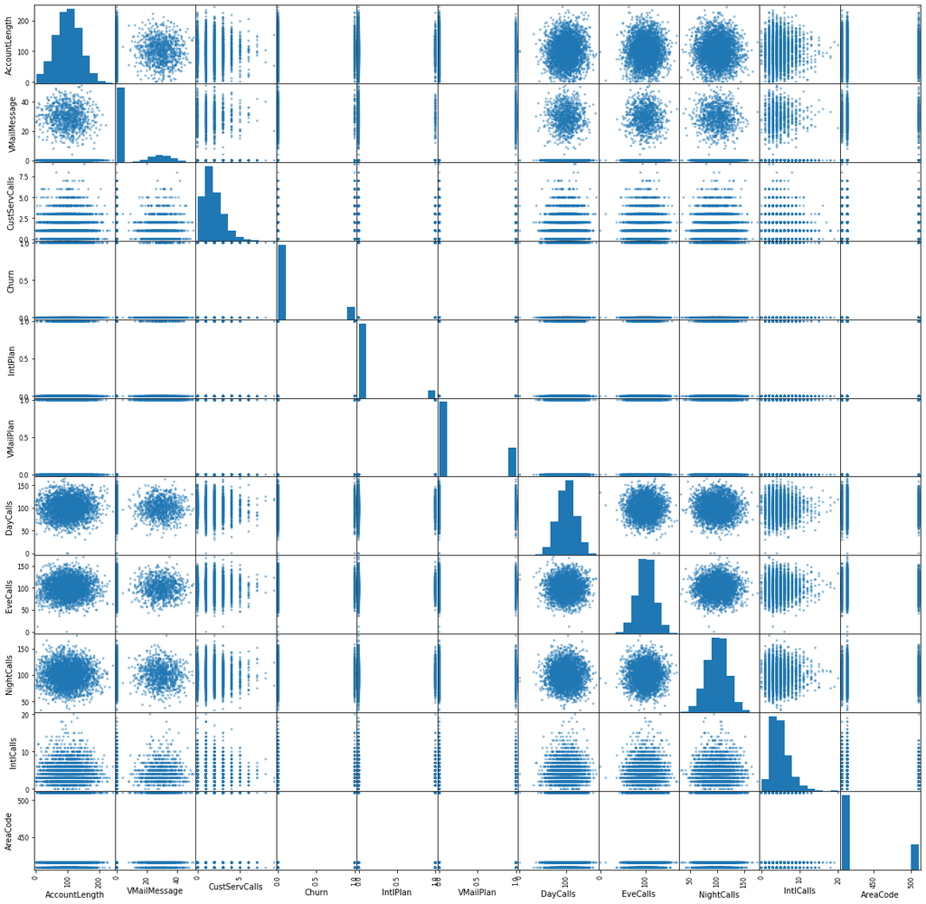

```python
axs = pd.plotting.scatter_matrix(df_num, figsize = (20, 20))
n = len(df_num.columns)
```

```python
histogram = df.select('DayMins').toPandas
```

```python
pip install handyspark
```

```python
pd.plotting.hist_frame(df)
```

[output not shown]

```python
from handyspark import * # tried to import handy spark to plot histogram but still didn't work.
```

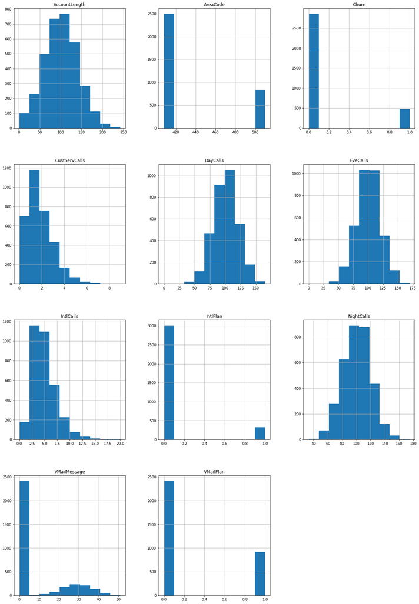

```python
# Histograms for the given numeric columns:
axs = pd.plotting.hist_frame(df_num,figsize=(20,30))
n = len(df_num.columns)
```

### To know the dependency of variable, the best method is to take a look into Correlation between them. Here we'll be creating correlation matrix to compare our numeric variables and to see their relationship.

```python
df_num.corr()
```

|  | AccountLength | VMailMessage | CustServCalls | Churn | IntlPlan | VMailPlan | DayCalls | EveCalls | NightCalls | IntlCalls | AreaCode |
| --- | --- | --- | --- | --- | --- | --- | --- | --- | --- | --- | --- |
| AccountLength | 1.000000 | -0.004628 | -0.003796 | 0.016541 | 0.024735 | 0.002918 | 0.038470 | 0.019260 | -0.013176 | 0.020661 | -0.012463 |
| VMailMessage | -0.004628 | 1.000000 | -0.013263 | -0.089728 | 0.008745 | 0.956927 | -0.009548 | -0.005864 | 0.007123 | 0.013957 | -0.001994 |
| CustServCalls | -0.003796 | -0.013263 | 1.000000 | 0.208750 | -0.024522 | -0.017824 | -0.018942 | 0.002423 | -0.012802 | -0.017561 | 0.027572 |
| Churn | 0.016541 | -0.089728 | 0.208750 | 1.000000 | 0.259852 | -0.102148 | 0.018459 | 0.009233 | 0.006141 | -0.052844 | 0.006174 |
| IntlPlan | 0.024735 | 0.008745 | -0.024522 | 0.259852 | 1.000000 | 0.006006 | 0.003755 | 0.006114 | 0.012451 | 0.017366 | 0.048551 |
| VMailPlan | 0.002918 | 0.956927 | -0.017824 | -0.102148 | 0.006006 | 1.000000 | -0.011086 | -0.006444 | 0.015553 | 0.007618 | -0.000747 |
| DayCalls | 0.038470 | -0.009548 | -0.018942 | 0.018459 | 0.003755 | -0.011086 | 1.000000 | 0.006462 | -0.019557 | 0.004574 | -0.009646 |
| EveCalls | 0.019260 | -0.005864 | 0.002423 | 0.009233 | 0.006114 | -0.006444 | 0.006462 | 1.000000 | 0.007710 | 0.017434 | -0.011886 |
| NightCalls | -0.013176 | 0.007123 | -0.012802 | 0.006141 | 0.012451 | 0.015553 | -0.019557 | 0.007710 | 1.000000 | 0.000305 | 0.016522 |
| IntlCalls | 0.020661 | 0.013957 | -0.017561 | -0.052844 | 0.017366 | 0.007618 | 0.004574 | 0.017434 | 0.000305 | 1.000000 | -0.024179 |
| AreaCode | -0.012463 | -0.001994 | 0.027572 | 0.006174 | 0.048551 | -0.000747 | -0.009646 | -0.011886 | 0.016522 | -0.024179 | 1.000000 |

## Now, after EDA, we need to convert our data so that it will be compatible for our model building process, so for all our categorical variable we use OneHotEncoder, String Indexer and Vector Assembler:

```python
cat_col = [i[0] for i in df.dtypes if i[1]=='string']
cols = df.columns
```

```python
from pyspark.ml.feature import StringIndexer, OneHotEncoderEstimator, VectorAssembler
stage = []
```

```python
## StringIndexer and Vector Assembler:
for i in cat_col:
    stridx = StringIndexer(inputCol=i, outputCol=i+'_index')
    encoder = OneHotEncoderEstimator(inputCols=[stridx.getOutputCol()], outputCols=[i+'enc'])
    stage += [stridx, encoder]
stage
```

```
[StringIndexer_14557a1af29e,
 OneHotEncoderEstimator_33b62ad8e90c,
 StringIndexer_c4e4c2e665b9,
 OneHotEncoderEstimator_d7d95e187a29]
```

```python
label_stringIdx = StringIndexer(inputCol='Churn', outputCol='label')
stage += [label_stringIdx]
df_num_feat = ['AccountLength', 'VMailMessage', 'DayMins', 'EveMins', 'NightMins', 'IntlMins', 'CustServCalls', 'IntlPlan',
               'VMailPlan', 'DayCalls', 'DayCharge', 'EveCalls', 'EveCharge', 'NightCalls', 'NightCharge', 'IntlCalls',
               'IntlCharge', 'AreaCode']
```

```python
## Vector Assembler:
assembler_Inputs = [c+'enc' for c in cat_col] + df_num_feat
assembler = VectorAssembler(inputCols=assembler_Inputs, outputCol='features')
stage += [assembler]
stage
```

```
[StringIndexer_14557a1af29e,
 OneHotEncoderEstimator_33b62ad8e90c,
 StringIndexer_c4e4c2e665b9,
 OneHotEncoderEstimator_d7d95e187a29,
 StringIndexer_1ae7a54df5d0,
 VectorAssembler_328b1a6f0705]
```

```python
from pyspark.ml import Pipeline
pln = Pipeline(stages=stage)
pln_model = pln.fit(df)
df = pln_model.transform(df)
selected_col = ['label', 'features']+cols
df = df.select(selected_col)
```

## And now, we are splitting our train & test dataset into 75% & 25%:

```python
train, test = df.randomSplit([0.75, 0.25])
print(train.count())
print(test.count())
```

```
2487
846
```

# Model Building

### To build a Machine learning model, we need to start with Model Selection Process:

### Then, import all the selected model Libraries

### To Evaluate your model, import Evaluator

### and To imporvise your model accuracy import all the parameter for ML Tuning

## here you gonna use:

### 1. Logistic Regression

### 2. Desicion Tree

### 3. Random Forest

# 1. Logistic Regression;

```python
from pyspark.ml.classification import LogisticRegression, DecisionTreeClassifier, RandomForestClassifier
from pyspark.ml.evaluation import BinaryClassificationEvaluator
from pyspark.ml.tuning import ParamGridBuilder, CrossValidator

#Importing 1st LR model and fiting this model plus checking row prediction and probability and churn

lr = LogisticRegression(featuresCol='features', labelCol='label')
lr_model = lr.fit(train)
lr_preds = lr_model.transform(test)
lr_preds.select('rawPrediction', 'probability', 'prediction', 'Churn').show()
```

```python
from pyspark.ml.classification import LogisticRegression, DecisionTreeClassifier, RandomForestClassifier
from pyspark.ml.evaluation import BinaryClassificationEvaluator
from pyspark.ml.tuning import ParamGridBuilder, CrossValidator

#Importing 1st LR model and fiting this model plus checking row prediction and probability and churn

lr = LogisticRegression(featuresCol='features', labelCol='label')
lr_model = lr.fit(train)
lr_preds = lr_model.transform(test)
lr_preds.select('rawPrediction', 'probability', 'prediction', 'Churn').show()
```

```
+--------------------+--------------------+----------+-----+
|       rawPrediction|         probability|prediction|Churn|
+--------------------+--------------------+----------+-----+
|[21.8735952411676...|[0.99999999968346...|       0.0|    0|
|[32.4817952334972...|[0.99999999999999...|       0.0|    0|
|[8.98767409334755...|[0.99987507525299...|       0.0|    0|
|[17.6133668378158...|[0.99999997758122...|       0.0|    0|
|[20.2625553183762...|[0.9999999984148,...|       0.0|    0|
|[28.2348669726801...|[0.99999999999945...|       0.0|    0|
|[20.3850494526420...|[0.99999999859755...|       0.0|    0|
|[21.9142084240192...|[0.99999999969606...|       0.0|    0|
|[6.85786513167504...|[0.99894994815014...|       0.0|    0|
|[19.3074347149274...|[0.99999999588009...|       0.0|    0|
|[21.6733493689518...|[0.99999999961329...|       0.0|    0|
|[19.5830009176437...|[0.99999999687240...|       0.0|    0|
|[18.4388569023411...|[0.99999999018011...|       0.0|    0|
|[13.3892689319801...|[0.99999846851156...|       0.0|    0|
|[33.4166564787697...|[0.99999999999999...|       0.0|    0|
|[7.76073000803932...|[0.99957403614497...|       0.0|    0|
|[21.7253565505838...|[0.99999999963288...|       0.0|    0|
|[26.1357501015436...|[0.99999999999553...|       0.0|    0|
|[12.2158033545251...|[0.99999504844211...|       0.0|    0|
|[23.2984695812231...|[0.99999999992386...|       0.0|    0|
+--------------------+--------------------+----------+-----+
only showing top 20 rows
```

```python
# Principle component Analysis:
evaluator = BinaryClassificationEvaluator()
evaluator.evaluate(lr_preds)
training_summary = lr_model.summary
roc = training_summary.roc.toPandas()
roc
```

|  | FPR | TPR |
| --- | --- | --- |
| 0 | 0.000000 | 0.000000 |
| 1 | 0.000000 | 0.080645 |
| 2 | 0.000000 | 0.145161 |
| 3 | 0.000000 | 0.209677 |
| 4 | 0.000000 | 0.274194 |
| ... | ... | ... |
| 101 | 0.973050 | 1.000000 |
| 102 | 0.984397 | 1.000000 |
| 103 | 0.995745 | 1.000000 |
| 104 | 1.000000 | 1.000000 |
| 105 | 1.000000 | 1.000000 |

106 rows × 2 columns

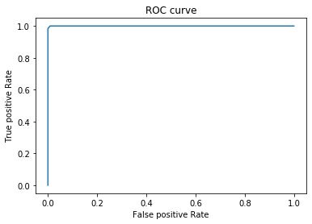

```python
# Ploting ROC Curve:

plt.plot(roc['FPR'],roc['TPR'])
plt.ylabel('True positive Rate')
plt.xlabel('False positive Rate')
plt.title('ROC curve')
plt.show()
```

# Grid Search:

### What is Grid Search ?

### Grid-searching is the process of scanning the data to configure optimal parameters for a given model. Depending on the type of model utilized, certain parameters are necessary. Grid-searching does NOT only apply to one model type. Grid-searching can be applied across machine learning to calculate the best parameters to use for any given model. It is important to note that Grid-searching can be extremely computationally expensive and may take your machine quite a long time to run. Grid-Search will build a model on each parameter combination possible. It iterates through every parameter combination and stores a model for each combination.

```python
# Building Paramter grid and Cross Validation:

lr_param_grid = (ParamGridBuilder()
              .addGrid(lr.regParam, [0.01, 0.1, 0.5, 1.0, 2.0])
              .addGrid(lr.maxIter, [1, 5, 10, 20, 50]).build())
cv = CrossValidator(estimator = lr,
                    estimatorParamMaps = lr_param_grid,
                    evaluator=evaluator, numFolds=10)
cv_model = cv.fit(train)
cv_lr_preds = cv_model.transform(test)
```

```python
cv_lr_preds.select('rawPrediction', 'probability', 'prediction', 'Churn').show()
```

```
+--------------------+--------------------+----------+-----+
|       rawPrediction|         probability|prediction|Churn|
+--------------------+--------------------+----------+-----+
|[3.14618342738365...|[0.95875807453952...|       0.0|    0|
|[3.75685167933004...|[0.97717594455733...|       0.0|    0|
|[1.60018704660023...|[0.83204452585255...|       0.0|    0|
|[2.60390194869948...|[0.93111228064190...|       0.0|    0|
|[2.64509968450858...|[0.93370831909596...|       0.0|    0|
|[3.41805392803966...|[0.96826402562431...|       0.0|    0|
|[2.79370154184769...|[0.94233451680049...|       0.0|    0|
|[2.58068355286873...|[0.92960801186368...|       0.0|    0|
|[2.25596503820539...|[0.90516382655275...|       0.0|    0|
|[2.54988611295338...|[0.92756586323280...|       0.0|    0|
|[2.84184751435158...|[0.94489573729933...|       0.0|    0|
|[2.10509716150359...|[0.89139760968968...|       0.0|    0|
|[2.71150299355063...|[0.93770200670617...|       0.0|    0|
|[2.32940243305723...|[0.91128303756293...|       0.0|    0|
|[3.9650576223823,...|[0.98138610503661...|       0.0|    0|
|[2.30305014988444...|[0.90912933623318...|       0.0|    0|
|[2.50262214575478...|[0.92432543782355...|       0.0|    0|
|[2.91467226573692...|[0.94856699174542...|       0.0|    0|
|[1.85213671043518...|[0.86437778213514...|       0.0|    0|
|[3.04704542302903...|[0.95465479746243...|       0.0|    0|
+--------------------+--------------------+----------+-----+
only showing top 20 rows
```

```python
preds = lr_model.transform(test)
```

```python
pred_summary = preds.select('rawPrediction', 'probability', 'prediction', 'Churn')
```

```python
pred_summary.show()
```

```
+--------------------+--------------------+----------+-----+
|       rawPrediction|         probability|prediction|Churn|
+--------------------+--------------------+----------+-----+
|[21.8735952411676...|[0.99999999968346...|       0.0|    0|
|[32.4817952334972...|[0.99999999999999...|       0.0|    0|
|[8.98767409334755...|[0.99987507525299...|       0.0|    0|
|[17.6133668378158...|[0.99999997758122...|       0.0|    0|
|[20.2625553183762...|[0.9999999984148,...|       0.0|    0|
|[28.2348669726801...|[0.99999999999945...|       0.0|    0|
|[20.3850494526420...|[0.99999999859755...|       0.0|    0|
|[21.9142084240192...|[0.99999999969606...|       0.0|    0|
|[6.85786513167504...|[0.99894994815014...|       0.0|    0|
|[19.3074347149274...|[0.99999999588009...|       0.0|    0|
|[21.6733493689518...|[0.99999999961329...|       0.0|    0|
|[19.5830009176437...|[0.99999999687240...|       0.0|    0|
|[18.4388569023411...|[0.99999999018011...|       0.0|    0|
|[13.3892689319801...|[0.99999846851156...|       0.0|    0|
|[33.4166564787697...|[0.99999999999999...|       0.0|    0|
|[7.76073000803932...|[0.99957403614497...|       0.0|    0|
|[21.7253565505838...|[0.99999999963288...|       0.0|    0|
|[26.1357501015436...|[0.99999999999553...|       0.0|    0|
|[12.2158033545251...|[0.99999504844211...|       0.0|    0|
|[23.2984695812231...|[0.99999999992386...|       0.0|    0|
+--------------------+--------------------+----------+-----+
only showing top 20 rows
```

### Model Accuracy:

```python
from pyspark.ml.evaluation import BinaryClassificationEvaluator
cl_eval = BinaryClassificationEvaluator()
cl_eval.evaluate(preds)
```

```
0.710633082061656
```

# Decision Tree Model:

```python
from pyspark.ml.classification import DecisionTreeClassifier, RandomForestClassifier
dt_clas = DecisionTreeClassifier(featuresCol='features', labelCol='label', maxDepth=30)
```

```python
dt_model = dt_clas.fit(train)
```

```python
dt_preds = dt_model.transform(test)
```

```python
dt_preds.select('rawPrediction', 'probability', 'prediction', 'Churn').show()
```

```
+-------------+--------------------+----------+-----+
|rawPrediction|         probability|prediction|Churn|
+-------------+--------------------+----------+-----+
|[1596.0,18.0]|[0.98884758364312...|       0.0|    0|
|[1596.0,18.0]|[0.98884758364312...|       0.0|    0|
|  [111.0,0.0]|           [1.0,0.0]|       0.0|    0|
|[1596.0,18.0]|[0.98884758364312...|       0.0|    0|
|[1596.0,18.0]|[0.98884758364312...|       0.0|    0|
|[1596.0,18.0]|[0.98884758364312...|       0.0|    0|
|[1596.0,18.0]|[0.98884758364312...|       0.0|    0|
|[1596.0,18.0]|[0.98884758364312...|       0.0|    0|
|  [227.0,0.0]|           [1.0,0.0]|       0.0|    0|
|[1596.0,18.0]|[0.98884758364312...|       0.0|    0|
|[1596.0,18.0]|[0.98884758364312...|       0.0|    0|
|   [33.0,0.0]|           [1.0,0.0]|       0.0|    0|
|[1596.0,18.0]|[0.98884758364312...|       0.0|    0|
|[1596.0,18.0]|[0.98884758364312...|       0.0|    0|
|[1596.0,18.0]|[0.98884758364312...|       0.0|    0|
|   [0.0,78.0]|           [0.0,1.0]|       1.0|    0|
|[1596.0,18.0]|[0.98884758364312...|       0.0|    0|
|[1596.0,18.0]|[0.98884758364312...|       0.0|    0|
|   [57.0,0.0]|           [1.0,0.0]|       0.0|    0|
|[1596.0,18.0]|[0.98884758364312...|       0.0|    0|
+-------------+--------------------+----------+-----+
only showing top 20 rows
```

### Model accuracy

```python
cl_eval.evaluate(dt_preds)
```

```
0.6910277624563339
```

# Random Forest Model

```python
rf_clas = RandomForestClassifier(featuresCol='features', labelCol='label', maxDepth=20)
```

```python
rf_model = rf_clas.fit(train)
```

```python
rf_preds = rf_model.transform(test)
```

```python
rf_preds.select('rawPrediction', 'probability', 'prediction', 'Churn').show()
```

```
+--------------------+--------------------+----------+-----+
|       rawPrediction|         probability|prediction|Churn|
+--------------------+--------------------+----------+-----+
|[18.7684115152388...|[0.93842057576194...|       0.0|    0|
|[18.1422099991127...|[0.90711049995563...|       0.0|    0|
|[15.8859167506582...|[0.79429583753291...|       0.0|    0|
|[18.1104313465722...|[0.90552156732861...|       0.0|    0|
|[18.0766094494938...|[0.90383047247469...|       0.0|    0|
|[18.2054411482020...|[0.91027205741010...|       0.0|    0|
|[18.2567272726657...|[0.91283636363328...|       0.0|    0|
|[17.9868127266418...|[0.89934063633209...|       0.0|    0|
|[18.0107655077615...|[0.90053827538807...|       0.0|    0|
|[17.7956080444907...|[0.88978040222453...|       0.0|    0|
|[17.9552032354061...|[0.89776016177030...|       0.0|    0|
|[13.7890780419106...|[0.68945390209553...|       0.0|    0|
|[18.2434515212792...|[0.91217257606396...|       0.0|    0|
|[18.1091482182563...|[0.90545741091281...|       0.0|    0|
|[18.4373100264949...|[0.92186550132474...|       0.0|    0|
|[13.7916048765155...|[0.68958024382577...|       0.0|    0|
|[18.0037021826054...|[0.90018510913027...|       0.0|    0|
|[18.3634378798853...|[0.91817189399426...|       0.0|    0|
|[16.5994942998491...|[0.82997471499245...|       0.0|    0|
|[18.7653462997199...|[0.93826731498599...|       0.0|    0|
+--------------------+--------------------+----------+-----+
only showing top 20 rows
```

### Model Accuracy:

```python
cl_eval.evaluate(rf_preds)
```

```
0.8450695593552748
```

```python
## Import gridsearch crossvalidator and performing hyperparameter tunning
from pyspark.ml.tuning import ParamGridBuilder, CrossValidator
```

```python
param_grid_lr = (ParamGridBuilder()
              .addGrid(lr.regParam, [0.01, 0.5, 2.0])
              .addGrid(lr.maxIter, [1, 5, 10]).build())
```

```python
cv = CrossValidator(estimator = lr,
                    estimatorParamMaps = param_grid_lr,
                    evaluator=cl_eval, numFolds=10)
```

```python
cv_model = cv.fit(train)
```

```python
cv_lr_preds = cv_model.transform(test)
```

```python
cv_lr_preds.select('rawPrediction', 'probability', 'prediction', 'Churn').show()
```

```
+--------------------+--------------------+----------+-----+
|       rawPrediction|         probability|prediction|Churn|
+--------------------+--------------------+----------+-----+
|[1.35471609792944...|[0.79489958302863...|       0.0|    0|
|[1.47043318103842...|[0.81312321848692...|       0.0|    0|
|[1.04791366762857...|[0.74037406489306...|       0.0|    0|
|[1.24212380348974...|[0.77593347664203...|       0.0|    0|
|[1.23467903386710...|[0.77463646525189...|       0.0|    0|
|[1.40421564980901...|[0.80285199642337...|       0.0|    0|
|[1.27568953391950...|[0.78171514646502...|       0.0|    0|
|[1.22458178600383...|[0.77286885340714...|       0.0|    0|
|[1.17406245021477...|[0.76387853754597...|       0.0|    0|
|[1.22097290953067...|[0.77223471811176...|       0.0|    0|
|[1.27592478340168...|[0.78175528597086...|       0.0|    0|
|[1.11607840336530...|[0.75326057621591...|       0.0|    0|
|[1.25899858497193...|[0.77885367159156...|       0.0|    0|
|[1.18737901835136...|[0.76627197606327...|       0.0|    0|
|[1.51743841170734...|[0.82016096392958...|       0.0|    0|
|[1.16377032482455...|[0.76201712734632...|       0.0|    0|
|[1.21458467696384...|[0.77110914936494...|       0.0|    0|
|[1.30246526182253...|[0.78624959020408...|       0.0|    0|
|[1.09213764309536...|[0.74878403997541...|       0.0|    0|
|[1.33732454991127...|[0.79204962034486...|       0.0|    0|
+--------------------+--------------------+----------+-----+
only showing top 20 rows
```

```python
cl_eval.evaluate(cv_lr_preds)
```

```
0.762407305264451
```

```python
## Performing grid search on Decision Tree Model:
param_grid_dt = (ParamGridBuilder()
              .addGrid(dt_clas.maxDepth, [1, 2, 5, 10, 20])
              .addGrid(dt_clas.maxBins, [20, 32, 40, 80]).build())
```

```python
cv_dt = CrossValidator(estimator=dt_clas,
                       estimatorParamMaps=param_grid_dt,
                      evaluator=cl_eval, numFolds=5)
```

```python
cv_dt_model = cv_dt.fit(train)
```

```python
cv_dt_preds = cv_dt_model.transform(test)
```

```python
cv_dt_preds.select('rawPrediction', 'probability', 'prediction', 'Churn').show()
```

```
+-------------+--------------------+----------+-----+
|rawPrediction|         probability|prediction|Churn|
+-------------+--------------------+----------+-----+
|[1610.0,29.0]|[0.98230628431970...|       0.0|    0|
|[1610.0,29.0]|[0.98230628431970...|       0.0|    0|
|  [111.0,0.0]|           [1.0,0.0]|       0.0|    0|
|[1610.0,29.0]|[0.98230628431970...|       0.0|    0|
|[1610.0,29.0]|[0.98230628431970...|       0.0|    0|
|[1610.0,29.0]|[0.98230628431970...|       0.0|    0|
|[1610.0,29.0]|[0.98230628431970...|       0.0|    0|
|[1610.0,29.0]|[0.98230628431970...|       0.0|    0|
|  [188.0,0.0]|           [1.0,0.0]|       0.0|    0|
|[1610.0,29.0]|[0.98230628431970...|       0.0|    0|
|[1610.0,29.0]|[0.98230628431970...|       0.0|    0|
|   [33.0,0.0]|           [1.0,0.0]|       0.0|    0|
|[1610.0,29.0]|[0.98230628431970...|       0.0|    0|
|[1610.0,29.0]|[0.98230628431970...|       0.0|    0|
|[1610.0,29.0]|[0.98230628431970...|       0.0|    0|
|   [0.0,82.0]|           [0.0,1.0]|       1.0|    0|
|[1610.0,29.0]|[0.98230628431970...|       0.0|    0|
|[1610.0,29.0]|[0.98230628431970...|       0.0|    0|
|   [54.0,0.0]|           [1.0,0.0]|       0.0|    0|
|[1610.0,29.0]|[0.98230628431970...|       0.0|    0|
+-------------+--------------------+----------+-----+
only showing top 20 rows
```

```python
cl_eval.evaluate(cv_dt_preds)
```

```
0.7277930992216708
```

param_grid_rf = (ParamGridBuilder() .addGrid(rf_clas.maxDepth, [2, 5, 10, 20, 30]) .addGrid(rf_clas.maxBins, [20, 32, 40, 80]) .addGrid(rf_clas.numTrees, [5, 10, 20, 40]).build())

cv_rf = CrossValidator(estimator=rf_clas, estimatorParamMaps=param_grid_rf, evaluator=cl_eval, numFolds=5)

cv_rf_model = cv_rf.fit(train)

cv_rf_preds = cv_rf_model.transform(test)

cv_rf_preds.select('rawPrediction', 'probability', 'prediction', 'Churn').show()

cl_eval.evaluate(cv_rf_preds)

```python
# Identifying best model
best_model = cv_model.bestModel
```

```python
predictions = best_model.transform(df)
```

```python
cl_eval.evaluate(predictions)
```

```
0.9645831971232506
```

```python
predictions.createOrReplaceTempView('predictions')
```

```python
predictions.show()
```

```
+-----+--------------------+-------------+------------+-------+-------+---------+--------+-------------+-----+--------+---------+--------+---------+--------+---------+----------+-----------+---------+----------+-----+--------+--------+--------------------+--------------------+----------+
|label|            features|AccountLength|VMailMessage|DayMins|EveMins|NightMins|IntlMins|CustServCalls|Churn|IntlPlan|VMailPlan|DayCalls|DayCharge|EveCalls|EveCharge|NightCalls|NightCharge|IntlCalls|IntlCharge|State|AreaCode|   Phone|       rawPrediction|         probability|prediction|
+-----+--------------------+-------------+------------+-------+-------+---------+--------+-------------+-----+--------+---------+--------+---------+--------+---------+----------+-----------+---------+----------+-----+--------+--------+--------------------+--------------------+----------+
|  0.0|(3400,[17,3106,33...|          128|          25|  265.1|  197.4|    244.7|    10.0|            1|    0|       0|        1|     110|    45.07|      99|    16.78|        91|      11.01|        3|       2.7|   KS|     415|382-4657|[1.12405676457800...|[0.75474042904810...|       0.0|
|  0.0|(3400,[5,3328,338...|          107|          26|  161.6|  195.5|    254.4|    13.7|            1|    0|       0|        1|     123|    27.47|     103|    16.62|       103|      11.45|        3|       3.7|   OH|     415|371-7191|[1.23770751534024...|[0.77516472206402...|       0.0|
|  0.0|(3400,[18,1581,33...|          137|           0|  243.4|  121.2|    162.6|    12.2|            0|    0|       0|        0|     114|    41.38|     110|     10.3|       104|       7.32|        5|      3.29|   NJ|     415|358-1921|[1.13522703347529...|[0.75680223915969...|       0.0|
|  0.0|(3400,[5,1082,338...|           84|           0|  299.4|   61.9|    196.9|     6.6|            2|    0|       1|        0|      71|     50.9|      88|     5.26|        89|       8.86|        7|      1.78|   OH|     408|375-9999|[1.09044235883389...|[0.74846501150709...|       0.0|
|  0.0|(3400,[34,1592,33...|           75|           0|  166.7|  148.3|    186.9|    10.1|            3|    0|       1|        0|     113|    28.34|     122|    12.61|       121|       8.41|        3|      2.73|   OK|     415|330-6626|[1.05220950547276...|[0.74119895910963...|       0.0|
|  0.0|(3400,[3,590,3382...|          118|           0|  223.4|  220.6|    203.9|     6.3|            0|    0|       1|        0|      98|    37.98|     101|    18.75|       118|       9.18|        6|       1.7|   AL|     510|391-8027|[1.13729917191319...|[0.75718341867402...|       0.0|
|  0.0|(3400,[24,911,338...|          121|          24|  218.2|  348.5|    212.6|     7.5|            3|    0|       0|        1|      88|    37.09|     108|    29.62|       118|       9.57|        7|      2.03|   MA|     510|355-9993|[1.10354056104212...|[0.75092291211159...|       0.0|
|  0.0|(3400,[28,2575,33...|          147|           0|  157.0|  103.1|    211.8|     7.1|            0|    0|       1|        0|      79|    26.69|      94|     8.76|        96|       9.53|        6|      1.92|   MO|     415|329-9001|[1.20275620054445...|[0.76901473332715...|       0.0|
|  0.0|(3400,[47,1412,33...|          117|           0|  184.5|  351.6|    215.8|     8.7|            1|    0|       0|        0|      97|    31.37|      80|    29.89|        90|       9.71|        4|      2.35|   LA|     408|335-4719|[1.21817785986411...|[0.77174272765423...|       0.0|
|  0.0|(3400,[0,2293,338...|          141|          37|  258.6|  222.0|    326.4|    11.2|            0|    0|       1|        1|      84|    43.96|     111|    18.87|        97|      14.69|        5|      3.02|   WV|     415|330-8173|[1.03858058159863...|[0.73857603550845...|       0.0|
|  1.0|(3400,[15,1815,33...|           65|           0|  129.1|  228.5|    208.8|    12.7|            4|    1|       0|        0|     137|    21.95|      83|    19.42|       111|        9.4|        6|      3.43|   IN|     415|329-6603|[0.80419961164663...|[0.69087210132270...|       0.0|
|  0.0|(3400,[25,1267,33...|           74|           0|  187.7|  163.4|    196.0|     9.1|            0|    0|       0|        0|     127|    31.91|     148|    13.89|        94|       8.82|        5|      2.46|   RI|     415|344-9403|[1.34426262013177...|[0.79319005381992...|       0.0|
|  0.0|(3400,[49,2101,33...|          168|           0|  128.8|  104.9|    141.1|    11.2|            1|    0|       0|        0|      96|     21.9|      71|     8.92|       128|       6.35|        2|      3.02|   IA|     408|363-1107|[1.42370249068992...|[0.80591819403219...|       0.0|
```

[output cut: 9 more lines]

```python
predictions.printSchema()
```

```
root
 |-- label: double (nullable = false)
 |-- features: vector (nullable = true)
 |-- AccountLength: integer (nullable = true)
 |-- VMailMessage: integer (nullable = true)
 |-- DayMins: double (nullable = true)
 |-- EveMins: double (nullable = true)
 |-- NightMins: double (nullable = true)
 |-- IntlMins: double (nullable = true)
 |-- CustServCalls: integer (nullable = true)
 |-- Churn: integer (nullable = true)
 |-- IntlPlan: integer (nullable = true)
 |-- VMailPlan: integer (nullable = true)
 |-- DayCalls: integer (nullable = true)
 |-- DayCharge: double (nullable = true)
 |-- EveCalls: integer (nullable = true)
 |-- EveCharge: double (nullable = true)
 |-- NightCalls: integer (nullable = true)
 |-- NightCharge: double (nullable = true)
 |-- IntlCalls: integer (nullable = true)
 |-- IntlCharge: double (nullable = true)
 |-- State: string (nullable = true)
 |-- AreaCode: integer (nullable = true)
 |-- Phone: string (nullable = true)
 |-- rawPrediction: vector (nullable = true)
 |-- probability: vector (nullable = true)
 |-- prediction: double (nullable = false)
```

```python
spark_2.sql('SELECT * FROM predictions').toPandas()
```

|  | label | features | AccountLength | VMailMessage | DayMins | EveMins | NightMins | IntlMins | CustServCalls | Churn | ... | NightCalls | NightCharge | IntlCalls | IntlCharge | State | AreaCode | Phone | rawPrediction | probability | prediction |
| --- | --- | --- | --- | --- | --- | --- | --- | --- | --- | --- | --- | --- | --- | --- | --- | --- | --- | --- | --- | --- | --- |
| 0 | 0.0 | (0.0, 0.0, 0.0, 0.0, 0.0, 0.0, 0.0, 0.0, 0.0, ... | 128 | 25 | 265.1 | 197.4 | 244.7 | 10.0 | 1 | 0 | ... | 91 | 11.01 | 3 | 2.70 | KS | 415 | 382-4657 | [1.124056764578008, -1.124056764578008] | [0.7547404290481033, 0.24525957095189657] | 0.0 |
| 1 | 0.0 | (0.0, 0.0, 0.0, 0.0, 0.0, 1.0, 0.0, 0.0, 0.0, ... | 107 | 26 | 161.6 | 195.5 | 254.4 | 13.7 | 1 | 0 | ... | 103 | 11.45 | 3 | 3.70 | OH | 415 | 371-7191 | [1.2377075153402428, -1.2377075153402428] | [0.7751647220640236, 0.22483527793597644] | 0.0 |
| 2 | 0.0 | (0.0, 0.0, 0.0, 0.0, 0.0, 0.0, 0.0, 0.0, 0.0, ... | 137 | 0 | 243.4 | 121.2 | 162.6 | 12.2 | 0 | 0 | ... | 104 | 7.32 | 5 | 3.29 | NJ | 415 | 358-1921 | [1.1352270334752976, -1.1352270334752976] | [0.7568022391596934, 0.24319776084030664] | 0.0 |
| 3 | 0.0 | (0.0, 0.0, 0.0, 0.0, 0.0, 1.0, 0.0, 0.0, 0.0, ... | 84 | 0 | 299.4 | 61.9 | 196.9 | 6.6 | 2 | 0 | ... | 89 | 8.86 | 7 | 1.78 | OH | 408 | 375-9999 | [1.090442358833898, -1.090442358833898] | [0.7484650115070911, 0.2515349884929089] | 0.0 |
| 4 | 0.0 | (0.0, 0.0, 0.0, 0.0, 0.0, 0.0, 0.0, 0.0, 0.0, ... | 75 | 0 | 166.7 | 148.3 | 186.9 | 10.1 | 3 | 0 | ... | 121 | 8.41 | 3 | 2.73 | OK | 415 | 330-6626 | [1.052209505472765, -1.052209505472765] | [0.7411989591096371, 0.25880104089036293] | 0.0 |
| ... | ... | ... | ... | ... | ... | ... | ... | ... | ... | ... | ... | ... | ... | ... | ... | ... | ... | ... | ... | ... | ... |
| 3328 | 0.0 | (0.0, 0.0, 0.0, 0.0, 0.0, 0.0, 0.0, 0.0, 0.0, ... | 192 | 36 | 156.2 | 215.5 | 279.1 | 9.9 | 2 | 0 | ... | 83 | 12.56 | 6 | 2.67 | AZ | 415 | 414-4276 | [1.2932150008200947, -1.2932150008200947] | [0.7846908642878493, 0.21530913571215074] | 0.0 |
| 3329 | 0.0 | (1.0, 0.0, 0.0, 0.0, 0.0, 0.0, 0.0, 0.0, 0.0, ... | 68 | 0 | 231.1 | 153.4 | 191.3 | 9.6 | 3 | 0 | ... | 123 | 8.61 | 4 | 2.59 | WV | 415 | 370-3271 | [1.235320058060568, -1.235320058060568] | [0.774748352228551, 0.225251647771449] | 0.0 |
| 3330 | 0.0 | (0.0, 0.0, 0.0, 0.0, 0.0, 0.0, 0.0, 0.0, 0.0, ... | 28 | 0 | 180.8 | 288.8 | 191.9 | 14.1 | 2 | 0 | ... | 91 | 8.64 | 6 | 3.81 | RI | 510 | 328-8230 | [1.125207095242439, -1.125207095242439] | [0.7549533012647491, 0.24504669873525092] | 0.0 |
| 3331 | 0.0 | (0.0, 0.0, 0.0, 0.0, 0.0, 0.0, 0.0, 0.0, 0.0, ... | 184 | 0 | 213.8 | 159.6 | 139.2 | 5.0 | 2 | 0 | ... | 137 | 6.26 | 10 | 1.35 | CT | 510 | 364-6381 | [1.0751156061732396, -1.0751156061732396] | [0.7455685447879946, 0.2544314552120054] | 0.0 |
| 3332 | 0.0 | (0.0, 0.0, 0.0, 0.0, 0.0, 0.0, 0.0, 0.0, 0.0, ... | 74 | 25 | 234.4 | 265.9 | 241.4 | 13.7 | 0 | 0 | ... | 77 | 10.86 | 4 | 3.70 | TN | 415 | 400-4344 | [1.2194293824882294, -1.2194293824882294] | [0.7719631157548681, 0.22803688424513188] | 0.0 |

3333 rows × 26 columns

# Thank You